# ASS1

# Problem Number 12

Book problem 2.73 surface roughness of pipe. Give an internal that will likely contain about 95% of all coated pipe roughness measurements. Using the Empirical Rule we calculate the mean and standard deviation to find the intervals where 95% of the data lie. So calculating the standard deviations I found that 95% of all coated pipe roughness measurements lie between 1.65-2.11.

# Problem Number 13

Book problem 2.80 Mongolian desert ants. a) Find the mean, median, and mode for the number of ant species discovered at the 11 sites. Mean is 12.82. Mode is 4 and 5. Medium is 5. b) c) Mean, median, and mode for the total plant cover percentage at the 5 dry steppe sites. Mean is 40.4. Median is 40. Mode is 40. d) Now for the 6 Gobi desert sites. Mean is 28. Median is 26. Mode is 30. e) Yes the center of total plant cover percentage distribution appears to be different in these two regions.

# Problem Number 14

Book problem 2.84.

```r
# a) Use a graphical method to describe the velocity distribution of galaxy cluster A1775.
gal = read.csv("GALAXY2.csv")
head(gal)
```

```
##   VELOCITY
## 1    22922
## 2    20210
## 3    21911
## 4    19225
## 5    18792
## 6    21993
```

```r
#plot(gal$Velocity, data = gal)

# b) Is there evidences to support the double cluster theory?

# c) Find the mean and standard deviation of the galaxy velocity.
mean(gal$VELOCITY)
```

```
## [1] 21448.25
```

```r
sd(gal$VELOCITY)
```

```
## [1] 1764.103
```

```r
# d) Suppose there is a galaxy with a velocity of 20,000 km/s. Is this galaxy likely to belong to A1775A or A1775B? Explain.
```

# Problem Number 15

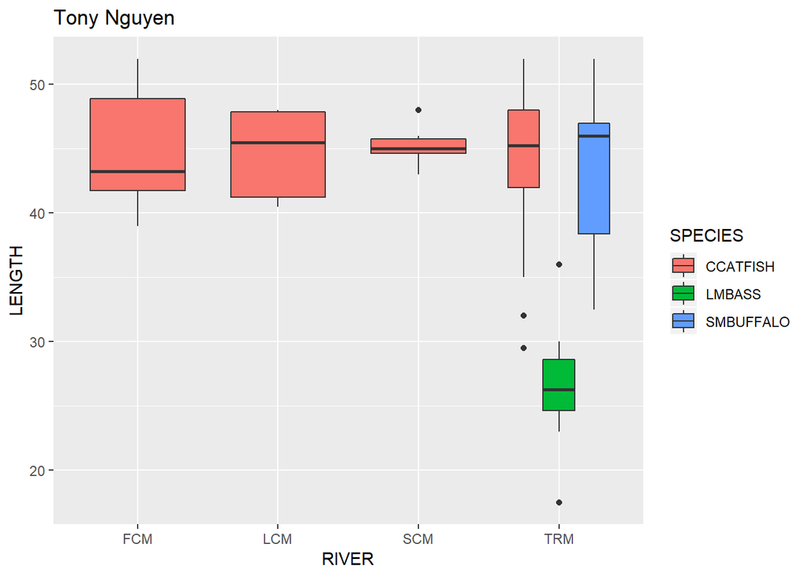

```r
library(ggplot2)
g1 = ggplot(ddt, aes(x = RIVER, y = LENGTH)) + geom_boxplot(aes(fill = SPECIES)) + ggtitle("Tony Nguyen")
print(g1)
```